# R Lab 1: Getting started with R and RStudio

CSSS Math Camp 2022

Jess Kunke, with some previous material from Jess Godwin

9/12/2022

## A few initial notes

- Desmos calculator
  - Handy tool for graphing functions!
  - https://www.desmos.com/calculator
- One of many R tutorials in case you’re interested: https://datacarpentry.org/r-socialsci/

## About R and RStudio

**R** is an open-source, free, statistical computing software environment.

**RStudio** is an application (a **graphical user interface** or GUI) for writing code, analyzing data and building packages with R.

RStudio has four main panels that allow you to organize your code and have a better user experience developing and using R code:

- **Source panel** where scripts and other files are edited
- **Console panel** where code is executed/run and output is printed
- **Environment panel** where you can see the objects you’ve created and look at your command history
- **Files/Plots/Help panel** where you can navigate files and folders, view plots, read and access help documentation for packages and functions

The meaning of these different terms and tasks will become clearer as we practice them.

If you open RStudio by opening the application directly instead of opening an R file, then you will not have the Source panel open and likely the Console panel will take up the entire left half of your window:

[figure not shown]

If instead you opened RStudio by clicking on an R file, this screenshot shows the likely order in which the four panes appear on your screen, though you can change the order under Preferences. Here I have two files open: RLab1 and a file whose name starts with exploratory-data-analysis-lesson. When the filename is red with an asterisk, as you see below for the file RLab1, the file has changes that have not been saved yet.

[figure not shown]

## R as a calculator

Let’s first see how we can use R as a calculator. Click in the Console pane and you should see the cursor blinking next to a greater-than symbol > which we call the command line. This is where you can type commands for R to run.

Let’s try a few different commands. To start, type 3+2 and press enter.

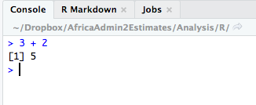

We can do basic mathematical computations using `+`, `-`, `*`, `/`, and `()`. Try the following lines, one line at a time. I recommend typing them yourselves instead of copying and pasting. You can skip the lines with text; these are called comments.

```r
2+3
6*7/2
# The number pi is hard coded into R
pi*1
# Why should the following two lines give you different results? What is the order of operations in each one?
6*3/2-3
6*3/(2-3)
# What will dividing by zero give you?
1/0
```

Try some on your own!

What about more complicated functions like exponents, square roots, trig functions and the natural logarithm?

```r
3^2
2^(3+2)
sqrt(9)
sin(2*pi)
log(1000)
exp(6.907755)
```

Note: `log()` computes the natural logarithm (base $e$) by default. See `?log` to compute a logarithm with a different base; how would you compute $\log_{10}(1000)$ and what should the correct answer be? Verify it by running your command into the R console.

## Creating objects and assigning values

So far, we are calculating things in R but they’re not being stored anywhere. And if we want to edit them, we need to retype them.

Sometimes, instead, we want to store numbers or data and then edit them. For data analysis and statistics, we need to be able to store and manipulate information instead of just computing things. Numbers, formulas, and other statistical information can be stored as in R. If you are using RStudio the objects you make and some information about them can be seen in the Environment panel.

For example, if you type the following line into the console,

```r
x = 4
```

you will notice that the blank command line reappears without any output having been printed. All R did was store the number 4 under the name `x`; we call this assigning the value 4 to the variable `x`, so you may hear people refer to `=` as an **assignment operator**. You can also see under the Environment panel that you now have a variable `x` that is equal to 4.

Some important notes:

- Object names are case-sensitive
- Object names should be meaningful and short (``best practice’’)
- Sometimes you will see `x <- 4` instead of `x = 4`. This is because earlier versions of R used `<-` to assign values to objects. For several versions now, R has accepted either of these assignment operators, but if you plan to use very old code or you want to be 100% backwards compatible, use `<-` instead.

Run the following code line by line to see how `x` changes each time. What value does `x` have after this whole code chunk?

```r
x = 9 # here we assign x the value 9, and R will not print anything
x # here we're not assigning anything; R will just print the current value of x
x = x + 2
x
x = x - 5
x
```

What happens if you try to use a variable you haven’t created yet? For example, what happens if you run this line of code?

```r
y - 3
```

Let’s try creating a little data set. Maybe we have data from a household survey on income, the number of household members, and the highest education level in the household. We can create of data, lists of values of the same type, using the function `c()`. (Here the c stands for concatenate, or to make into a chain.)

Objects can be numbers, strings, matrices, or even more complicated `R` objects. Examples of `R` object types:

- integer, numeric, string
- vector, matrix, list
- data.frame
- factor
- lm object (linear model object, e.g. regression)
- formula

```r
id = 1:5
id # to see what this new id object looks like
typeof(id)
hh_income = c(32, 40, 36, 55, 18)
hh_members = c(3, 5, 5, 3, 4)
hh_edu = c("high school", "high school", "some graduate", "college", "high school")
```

We can combine these individual vectors into a data set:

```r
hh_data = data.frame(id, hh_income, hh_members, hh_edu)
```

We can see the types of our data columns (and some other information about the data set) using `str`:

```r
str(hh_data)
```

## R scripts and best practice

Typing commands directly into the console is nice sometimes, especially for developing code or testing things out. If you quit, though, the commands you typed and the results you obtained disappear and will not be there when you reopen RStudio later. To save them, you can store the commands in a file. The simplest kind of file is called a **script**.

Open a new .R script by clicking File $\rightarrow$ New File $\rightarrow$ R Script. This will appear in the Source panel of your RStudio window.

Copy and paste the following lines of code into your script file:

```r
id = 1:5
id # to see what this new id object looks like
typeof(id)
hh_income = c(32, 40, 36, 55, 18)
hh_members = c(3, 5, 5, 3, 4)
hh_edu = c("high school", "high school", "some graduate", "college", "high school")
hh_data = data.frame(id, hh_income, hh_members, hh_edu)
str(hh_data)
```

You can run code many different ways. Here are two:

1. Execute a chunk of the code by highlighting it in the script file and typing command-return (Mac) or control-return (PC).
2. Alternatively, you can run the code line by line. Place your cursor anywhere on the first line you want to run and type command-return (Mac) or control-return (PC). If you keep repeating this key sequence, you will keep running the lines of code in sequence. Try this out!

### Comments

It is good practice to annotate your scripts by including comments that describe what your code does. To do this, you can include lines that start with `#`; these lines will be treated as comments and they are not run as code. For example, above I made a comment to explain that the second line lets us see what the `id` object looks like.

You can also use the comment character `#` to “comment out” code. For example, what value does `x` have after this code chunk?

```r
x = 9
x = x + 2
x = x - 5
```

What about after this code chunk, which is the same except the middle line is commented out?

```r
x = 9
# x = x + 2
x = x - 5
```

### When is code run?

Note that code in your script file is not run until you run it. Therefore, it is also not necessarily run in the order that it is in your script; it is run in whatever order you execute it. For instance, if you quit RStudio, reopen it, and run just the last line of the script, you will receive an error.

Also, if you edit code in the script, it does not update the variables you have already created in your working environment unless you rerun the code. Let’s practice this with our data set example above.

Related: Where does the name Environment panel come from? From the time you open RStudio to the time you close it, we say you are running a **session**. When you create variables like this, they exist in your **working environment** which means that they are defined and accessible within R. This is separate from whether they are stored somewhere on your computer for you to access after you close R. This means two things, which will be particularly relevant when we read in and manipulate data sets:

1. When you open R or RStudio, data on your computer or anywhere else is not automatically available to analyze in R; first you have to load it and store it as an R object.
2. Once you create an object in R, the object exists only during this session unless you save it to a file if you want to be able to access it again later without recreating it. If the object takes a long time to create, this is the best option. Otherwise, the better alternative is usually to save the code you used to create the object, and then you can recreate it easily anytime you need it.